# R Notebook

```r
library(tidyverse)
library(tidyverse)
library(e1071)
library(infer)
```

We are interested in how bill length differ between the three species of penguin (Adelie, Chinstrap & Gentoo) in this dataset.

1. Explore the dataset using visualisations, and keep in mind the question you’re trying to answer above.
- The histogram shows the bill length and count of penguins separated by species of Adelie, Chinstrap and Gentoo.
- The separate graphs shows the individual count of each species - you can see that in the study Adelie has the highest count, Gentoo has the second highest count and Chinstrap has the lowest count number.
- The bill length of each species shows that on average Adelie penguins has the lowest bill length with both Chinstrap and Gentoo having higher bill lengths.
- The longest bill length is found in the Gentoo species and the lowest bill length is found in the Adeline species.

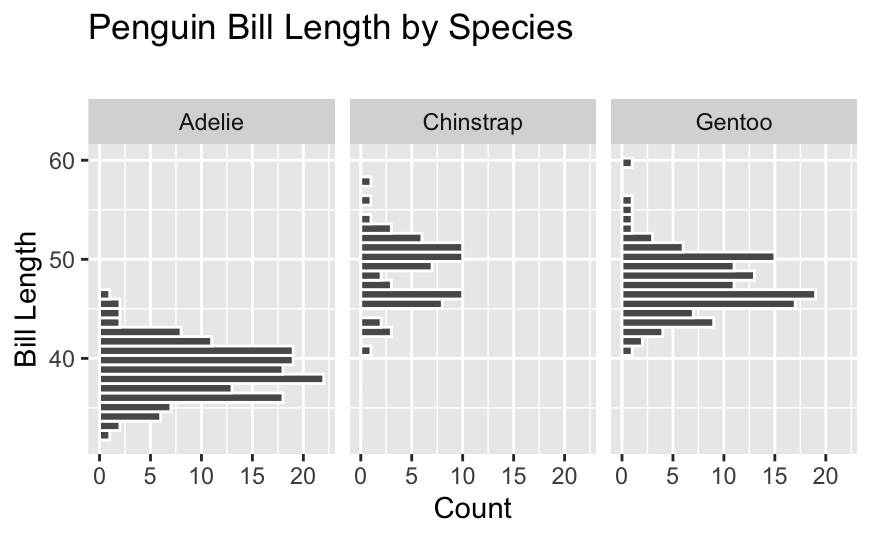

| species | mean_bill_length |
| --- | --- |
| Adelie | 38.79139 |
| Chinstrap | 48.83382 |
| Gentoo | 47.50488 |

| species | median_bill_length |
| --- | --- |
| Adelie | 38.80 |
| Chinstrap | 49.55 |
| Gentoo | 47.30 |

| species | sd |
| --- | --- |
| Adelie | 2.663405 |
| Chinstrap | 3.339256 |
| Gentoo | 3.081857 |

| species | skewness |
| --- | --- |
| Adelie | 0.16006382 |
| Chinstrap | -0.08856427 |
| Gentoo | 0.64316334 |

3. Perform a suitable hypothesis test to check whether the mean bill length of Gentoo is significantly longer than the mean bill length of Adelie.

H0: gentoo_mean_length - adelie_mean_length > 0 Ha: gentoo_mean_length - adelie_mean_length = 0

| species | island | bill_length_mm | bill_depth_mm | flipper_length_mm | body_mass_g | sex | year |
| --- | --- | --- | --- | --- | --- | --- | --- |
| Adelie | Torgersen | 39.1 | 18.7 | 181 | 3750 | male | 2007 |
| Adelie | Torgersen | 39.5 | 17.4 | 186 | 3800 | female | 2007 |
| Adelie | Torgersen | 40.3 | 18.0 | 195 | 3250 | female | 2007 |
| Adelie | Torgersen | 36.7 | 19.3 | 193 | 3450 | female | 2007 |
| Adelie | Torgersen | 39.3 | 20.6 | 190 | 3650 | male | 2007 |
| Adelie | Torgersen | 38.9 | 17.8 | 181 | 3625 | female | 2007 |
| Adelie | Torgersen | 39.2 | 19.6 | 195 | 4675 | male | 2007 |
| Adelie | Torgersen | 34.1 | 18.1 | 193 | 3475 | NA | 2007 |
| Adelie | Torgersen | 42.0 | 20.2 | 190 | 4250 | NA | 2007 |
| Adelie | Torgersen | 37.8 | 17.1 | 186 | 3300 | NA | 2007 |

[output cut: 264 more lines]

| species | n() |
| --- | --- |
| Adelie | 151 |
| Gentoo | 123 |

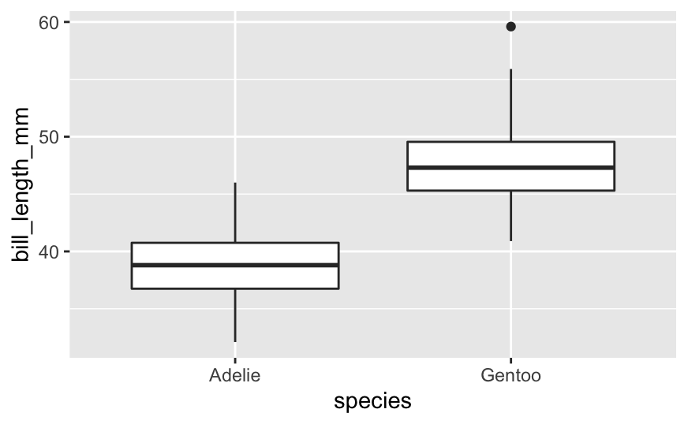

```r
null_distribution <- penguin_filter %>%
  specify(response = bill_length_mm, explanatory = species) %>%
  hypothesise(null = "point") %>%
  generate(reps = 1000, type = "permute") %>%
  calculate(stat = "diff in means", order = c("Adelie", "Gentoo"))
```

```
Error: You must specify exactly one of `p`, `mu`, `med`, or `sigma`.
```

| stat |
| --- |
| -8.713487 |

```
`direction` should be one of `"less"`, `"left"`, `"greater"`, ",
"`"right"`, `"two-sided"`, `"both"`, `"two_sided"`, or `"two sided"`.
```

[figure not shown]

```r
null_distribution %>%
  visualise(bins = 15) +
  shade_p_value(obs_stat = observed_stat, direction = "bootstrap")
```

```r
null_distribution %>%
  get_p_value(obs_stat = observed_stat, direction = "bootstrap")
```

```
Error: The provided value for `direction` is not appropriate. Possible values are "less", "greater", "two-sided", "left", "right", "both", "two_sided", or "two sided"
```

```r
p_value == 0
```

```
Error in p_value == 0 :
  comparison (1) is possible only for atomic and list types
```